# Evaluación actividad Juegos Olímpicos

Alumno: Daniel García Loyola  
Profesor: Israel Naranjo Retamal  
Ramo: Minería de datos (MDY7101)  
Sección: 002D  
Entrega: 06/05/2020

```python
import pandas as pd
import numpy as np
import matplotlib.pyplot as plt
import seaborn as sns
```

## Cargando datos de juegos olímpicos

```python
data_file="../data/original/JuegosOlimpicos.csv"
data = pd.read_csv(data_file)
data.shape
```

```
(271116, 15)
```

Ajustando títulos de columnas al dataframe

```python
data.columns=["ID", "NombreAtleta", "Sexo", "Edad", "Altura", "Peso", "Equipo", "Comite", "JuegosOlimpicos", "Año", "Temporada", "Ciudad", "Deporte", "Competencia", "Medalla"]
data.columns
```

```
Index(['ID', 'NombreAtleta', 'Sexo', 'Edad', 'Altura', 'Peso', 'Equipo',
       'Comite', 'JuegosOlimpicos', 'Año', 'Temporada', 'Ciudad', 'Deporte',
       'Competencia', 'Medalla'],
      dtype='object')
```

```python
data.head()
```

|  | ID | NombreAtleta | Sexo | Edad | Altura | Peso | Equipo | Comite | JuegosOlimpicos | Año | Temporada | Ciudad | Deporte | Competencia | Medalla |
| --- | --- | --- | --- | --- | --- | --- | --- | --- | --- | --- | --- | --- | --- | --- | --- |
| 0 | 1 | A Dijiang | M | 24.0 | 180.0 | 80.0 | China | CHN | 1992 Summer | 1992 | Summer | Barcelona | Basketball | Basketball Men's Basketball | NaN |
| 1 | 2 | A Lamusi | M | 23.0 | 170.0 | 60.0 | China | CHN | 2012 Summer | 2012 | Summer | London | Judo | Judo Men's Extra-Lightweight | NaN |
| 2 | 3 | Gunnar Nielsen Aaby | M | 24.0 | NaN | NaN | Denmark | DEN | 1920 Summer | 1920 | Summer | Antwerpen | Football | Football Men's Football | NaN |
| 3 | 4 | Edgar Lindenau Aabye | M | 34.0 | NaN | NaN | Denmark/Sweden | DEN | 1900 Summer | 1900 | Summer | Paris | Tug-Of-War | Tug-Of-War Men's Tug-Of-War | Gold |
| 4 | 5 | Christine Jacoba Aaftink | F | 21.0 | 185.0 | 82.0 | Netherlands | NED | 1988 Winter | 1988 | Winter | Calgary | Speed Skating | Speed Skating Women's 500 metres | NaN |

## Explorando datos de juegos olímpicos

```python
data.describe(include="all")
```

|  | ID | NombreAtleta | Sexo | Edad | Altura | Peso | Equipo | Comite | JuegosOlimpicos | Año | Temporada | Ciudad | Deporte | Competencia | Medalla |
| --- | --- | --- | --- | --- | --- | --- | --- | --- | --- | --- | --- | --- | --- | --- | --- |
| count | 271116.000000 | 271116 | 271116 | 261642.000000 | 210945.000000 | 208241.000000 | 271116 | 271116 | 271116 | 271116.000000 | 271116 | 271116 | 271116 | 271116 | 39783 |
| unique | NaN | 134732 | 2 | NaN | NaN | NaN | 1184 | 230 | 51 | NaN | 2 | 42 | 66 | 765 | 3 |
| top | NaN | Robert Tait McKenzie | M | NaN | NaN | NaN | United States | USA | 2000 Summer | NaN | Summer | London | Athletics | Football Men's Football | Gold |
| freq | NaN | 58 | 196594 | NaN | NaN | NaN | 17847 | 18853 | 13821 | NaN | 222552 | 22426 | 38624 | 5733 | 13372 |
| mean | 68248.954396 | NaN | NaN | 25.556898 | 175.338970 | 70.702393 | NaN | NaN | NaN | 1978.378480 | NaN | NaN | NaN | NaN | NaN |
| std | 39022.286345 | NaN | NaN | 6.393561 | 10.518462 | 14.348020 | NaN | NaN | NaN | 29.877632 | NaN | NaN | NaN | NaN | NaN |
| min | 1.000000 | NaN | NaN | 10.000000 | 127.000000 | 25.000000 | NaN | NaN | NaN | 1896.000000 | NaN | NaN | NaN | NaN | NaN |
| 25% | 34643.000000 | NaN | NaN | 21.000000 | 168.000000 | 60.000000 | NaN | NaN | NaN | 1960.000000 | NaN | NaN | NaN | NaN | NaN |
| 50% | 68205.000000 | NaN | NaN | 24.000000 | 175.000000 | 70.000000 | NaN | NaN | NaN | 1988.000000 | NaN | NaN | NaN | NaN | NaN |
| 75% | 102097.250000 | NaN | NaN | 28.000000 | 183.000000 | 79.000000 | NaN | NaN | NaN | 2002.000000 | NaN | NaN | NaN | NaN | NaN |
| max | 135571.000000 | NaN | NaN | 97.000000 | 226.000000 | 214.000000 | NaN | NaN | NaN | 2016.000000 | NaN | NaN | NaN | NaN | NaN |

## Visualizando info del dataframe

```python
data.info()
```

```
<class 'pandas.core.frame.DataFrame'>
RangeIndex: 271116 entries, 0 to 271115
Data columns (total 15 columns):
 #   Column           Non-Null Count   Dtype
---  ------           --------------   -----
 0   ID               271116 non-null  int64
 1   NombreAtleta     271116 non-null  object
 2   Sexo             271116 non-null  object
 3   Edad             261642 non-null  float64
 4   Altura           210945 non-null  float64
 5   Peso             208241 non-null  float64
 6   Equipo           271116 non-null  object
 7   Comite           271116 non-null  object
 8   JuegosOlimpicos  271116 non-null  object
 9   Año              271116 non-null  int64
 10  Temporada        271116 non-null  object
 11  Ciudad           271116 non-null  object
 12  Deporte          271116 non-null  object
 13  Competencia      271116 non-null  object
 14  Medalla          39783 non-null   object
dtypes: float64(3), int64(2), object(10)
memory usage: 31.0+ MB
```

## Verificando tipos de datos

```python
data.dtypes
```

```
ID                   int64
NombreAtleta        object
Sexo                object
Edad               float64
Altura             float64
Peso               float64
Equipo              object
Comite              object
JuegosOlimpicos     object
Año                  int64
Temporada           object
Ciudad              object
Deporte             object
Competencia         object
Medalla             object
dtype: object
```

## Visualizando elementos nulos

```python
data["Medalla"].isnull().sum()
```

```
231333
```

# Anecdotas de los juegos olímpicos

1. Dorando Pietri el perdedor más famoso de la historia. El atleta italiano, pastelero de profesión, se desplomó varias veces antes de llegar a la meta. Un juez y el entonces periodista Arthur Conan Doyle le arrastraron hasta la línea de llegada. ¿En qué año sucedió esta anécdota?

```python
atleta = data.loc[:, "NombreAtleta"]=="Dorando Pietri"
competencia = data.loc[:, "Competencia"].str.contains("Marathon")
anio = data.loc[:, "Año"]==1908
dorando = data.loc[atleta & competencia & anio]
dorando[["Año", "Temporada", "Ciudad", "Deporte", "Competencia"]]
```

|  | Año | Temporada | Ciudad | Deporte | Competencia |
| --- | --- | --- | --- | --- | --- |
| 188632 | 1908 | Summer | London | Athletics | Athletics Men's Marathon |

Dorando fue aclamado por su fortaleza al competir y perder multiples veces la conciencia durante la maratón de las olimpiadas de Londres en 1908, pero aunque fue descalificado, igualmente llego al final de la competencia.

2. Wilma Rudolph junto a su elegancia y belleza, le valió el sobrenombre de Gacela negra es una de esas historias de superación que emociona. De familia humilde y vigésima de veintidós hermanos, pasó varios años sin caminar cuando era pequeña a causa de una poliomielitis. ¿Cuál(es) son sus logros que la llevaron a tener el reconocimiento de superación?

```python
nombre = data.loc[:, "NombreAtleta"].str.contains("Wilma")
apellido = data.loc[:, "NombreAtleta"].str.contains("Rudolph")
wilma = data.loc[nombre & apellido]
wilma[["Edad", "Año", "Temporada", "Ciudad", "Deporte", "Competencia", "Medalla"]]
```

|  | Edad | Año | Temporada | Ciudad | Deporte | Competencia | Medalla |
| --- | --- | --- | --- | --- | --- | --- | --- |
| 205798 | 16.0 | 1956 | Summer | Melbourne | Athletics | Athletics Women's 200 metres | NaN |
| 205799 | 16.0 | 1956 | Summer | Melbourne | Athletics | Athletics Women's 4 x 100 metres Relay | Bronze |
| 205800 | 20.0 | 1960 | Summer | Roma | Athletics | Athletics Women's 100 metres | Gold |
| 205801 | 20.0 | 1960 | Summer | Roma | Athletics | Athletics Women's 200 metres | Gold |
| 205802 | 20.0 | 1960 | Summer | Roma | Athletics | Athletics Women's 4 x 100 metres Relay | Gold |

Wilma Rudolph, participo por primera vez en las olimpiadas de Melbourne en el año 1956 con tan solo 16 años, participó en dos disciplinas 200 metros planos y en el relevo 4x100 metros, en esta última competición obtubo su primera medalla de bronce. En los juegos olímpicos de Roma el año 1960, obtubo tres medallas de oro con tan solo 20 años de edad, las competiciones que gano fueron 100 y 200 metros planos y en el relevo de 4x100 metros.

3. La esgrimista Helene Mayer fue la única judía que desfiló bajo la bandera Nazi y estrechó la mano de Hitler al recibir su medalla de plata. ¿En qué JJOO sucedió?

```python
nombre = data.loc[:, "NombreAtleta"].str.contains("Helene")
apellido = data.loc[:, "NombreAtleta"].str.contains("Mayer")
anio = data.loc[:, "Año"]==1936
helene = data.loc[nombre & apellido & anio]
helene[["Ciudad", "Año", "Deporte", "Competencia", "Medalla"]]
```

|  | Ciudad | Año | Deporte | Competencia | Medalla |
| --- | --- | --- | --- | --- | --- |
| 153392 | Berlin | 1936 | Fencing | Fencing Women's Foil, Individual | Silver |

Helene Mayer en el año 1936, en los juegos realizados en Berlin Alemania, gano la medalla de plata en esgrima femenina representando a Alemania, esto permitio que los juegos se realizaran y finalmente evito el boicot internacional, ya que Hittler no quería que ningún deportista Judío representara a la Alemania Nazi de ese entonces.

4. Bob Beamon el monstruo que saltó ocho metros noventa centímetros, en el salto del siglo ¿En qué temporada de los JJOO lo realizo?

```python
nombre = data.loc[:, "NombreAtleta"].str.contains("Bob")
apellido = data.loc[:, "NombreAtleta"].str.contains("Beamon")
anio = data.loc[:, "Año"]==1968
bob = data.loc[nombre & apellido & anio]
bob[["Ciudad", "Año", "JuegosOlimpicos",  "Deporte", "Competencia", "Medalla"]]
```

|  | Ciudad | Año | JuegosOlimpicos | Deporte | Competencia | Medalla |
| --- | --- | --- | --- | --- | --- | --- |
| 16830 | Mexico City | 1968 | 1968 Summer | Athletics | Athletics Men's Long Jump | Gold |

Robert Bob Beamon obtuvo el record de salto de longitud alcanzando la distancia de 8 metros y 90 centimetros en la ciudad de Mejico en el año 1968, en los juegos olímpicos de verano, dicho récord perduró durante 22 años, 10 meses y 22 días, hasta ser superado en la final del Mundial de Tokio 1991 por Mike Powell (8,95 metros).

5. Jim Thorpe indio piel roja, ganador olímpico, vio truncada su carrera cuando le retiraron las medallas y no fue hasta 70 años después cuando Samaranch reconoció el error y devolvió las insignias a sus hijos. ¿Dónde logro las medallas y en que disciplina?

```python
nombre = data.loc[:, "NombreAtleta"].str.contains("Jim")
apellido = data.loc[:, "NombreAtleta"].str.contains("Thorpe")
medallas = data.loc[:, "Medalla"]=="Gold"
jim = data.loc[nombre & apellido & medallas]
jim[["JuegosOlimpicos", "Ciudad", "Deporte", "Competencia", "Medalla"]]
```

|  | JuegosOlimpicos | Ciudad | Deporte | Competencia | Medalla |
| --- | --- | --- | --- | --- | --- |
| 239627 | 1912 Summer | Stockholm | Athletics | Athletics Men's Pentathlon | Gold |
| 239628 | 1912 Summer | Stockholm | Athletics | Athletics Men's Decathlon | Gold |

Jim Thorpe gano las medallas de oro en el Pentatlon y Decatlon en las olimpiadas de verano en 1912, realizadas en Estocolmo, estas fueron retiradas ya que Jim habia jugado béisbol de manera profesional antes de presentarse a las olimpiadas.

6. ¿Puede alguien ganar una maratón corriendo descalzo y tres semanas después de ser operado de apendicitis? El etíope Abebe Bikila lo logró más tarde quedó parapléjico, pero no se rindió y siguió compitiendo con el mismo espíritu de lucha. ¿Sabes en que año logro su hazaña?

```python
nombre = data.loc[:, "NombreAtleta"].str.contains("Abebe")
apellido = data.loc[:, "NombreAtleta"].str.contains("Bikila")
anio = data.loc[:, "Año"]==1960
abebe = data.loc[nombre & apellido & anio]
abebe[["JuegosOlimpicos", "Ciudad", "Deporte", "Competencia", "Medalla"]]
```

|  | JuegosOlimpicos | Ciudad | Deporte | Competencia | Medalla |
| --- | --- | --- | --- | --- | --- |
| 21706 | 1960 Summer | Roma | Athletics | Athletics Men's Marathon | Gold |

Lo consiguio en los juegos olímpicos de Roma en 1960, además estableció una nueva marca en la maratón teniendo un tiempo de 2 horas con doce minutos y doce segundos, en 1969 el atleta se vio involucrado en un accidente de autos cerca de Adís Abeba, en Etiopía, lo que le produjo una paraplejia. Bikila nunca pudo reponerse totalmente del accidente, y falleció a los 41 años de edad.

7. Abandonado al nacer, a los nueve años fumaba y bebía. Vivió con miedos y fobias, condicionado por su elección sexual. Dura realidad la de Louganis que acabó transformando en éxito y superación, al obtener varios oros olímpicos. ¿Sabes en que disciplina logro el podio?

```python
apellido = data.loc[:, "NombreAtleta"].str.contains("Louganis")
medallas = data.loc[:, "Medalla"].isin(["Gold", "Silver", "Bronze"])
greg = data.loc[apellido & medallas]
greg[["NombreAtleta", "Edad", "Deporte", "Competencia", "JuegosOlimpicos", "Ciudad", "Medalla"]]
```

|  | NombreAtleta | Edad | Deporte | Competencia | JuegosOlimpicos | Ciudad | Medalla |
| --- | --- | --- | --- | --- | --- | --- | --- |
| 142835 | Gregory Efthimios "Greg" Louganis | 16.0 | Diving | Diving Men's Platform | 1976 Summer | Montreal | Silver |
| 142836 | Gregory Efthimios "Greg" Louganis | 24.0 | Diving | Diving Men's Springboard | 1984 Summer | Los Angeles | Gold |
| 142837 | Gregory Efthimios "Greg" Louganis | 24.0 | Diving | Diving Men's Platform | 1984 Summer | Los Angeles | Gold |
| 142838 | Gregory Efthimios "Greg" Louganis | 28.0 | Diving | Diving Men's Springboard | 1988 Summer | Seoul | Gold |
| 142839 | Gregory Efthimios "Greg" Louganis | 28.0 | Diving | Diving Men's Platform | 1988 Summer | Seoul | Gold |

Greg Louganis, compitio en cuatro olimpiadas, consiguió medalla de plata en los juegos de 1976 en Montreal (salto en plataforma) con tan solo 16 años de edad, luego participó en juegos realizados en Los Angeless 1984 y Seoul 1988 logrando medallas de oro en las especialidades de salto en trampolín y salto en plataformas consecutivamente.

# Anecdotas de Chilenos en juegos olímpicos

Definiendo variables comunes para estos deportistas.

```python
equipo = data.loc[:, "Equipo"]=="Chile"
campos =["NombreAtleta", "JuegosOlimpicos", "Ciudad", "Deporte", "Competencia"]
```

8. Martín Vargas pelea con pañal  
A los 17 años, Martín Vargas asistió a los JJ.OO, pero solo alcanzó a combatir una vez, ya que fue eliminado por el colombiano Calixto Pérez en estrecho veredicto. Su explicación fue contundente: "Estaba enfermo del estómago por comer fruta mal lavada. Tuve que pelear con pañales, lo que me perjudicó. En aquella ocasión Pérez me calzó un derechazo a la cara que me tiró al suelo. Me levanté prontamente y no hubo cuenta, pero estaba nocaut. Todo el estadio nos aplaudió mucho”.

```python
apellido = data.loc[:, "NombreAtleta"].str.contains("Vargas Fuentes")
dale_martin = data.loc[apellido & equipo]
dale_martin[["NombreAtleta", "Competencia", "JuegosOlimpicos", "Ciudad"]]
```

|  | NombreAtleta | Competencia | JuegosOlimpicos | Ciudad |
| --- | --- | --- | --- | --- |
| 250167 | Martn Adolfo Vargas Fuentes | Boxing Men's Flyweight | 1972 Summer | Munich |

Aquella pelea de Martin Vargas ocurrio en los juegos olímpicos de Munich en 1972, en la categoría de peso mosca.

9. El primer eliminado por indisciplina  
Francisco Arellano, el "Mono", era hermano de David, el mártir colocolino fallecido en 1927, en Valladolid. Un año después de la desgracia, era uno de los pilares del equipo de fútbol que perdió con Portugal 4 a 2 en la primera fase. Arellano no jugó, pues fue devuelto en el mismo barco en el que había llegado. "Me echaron sin escucharme. No fue mi culpa, lo hice para defender a un compañero. Me devolvieron con poca plata y en Buenos Aires pasé un día sin comer". La prensa de la época no da detalles del incidente (aparentemente, una pelea a golpes), aunque otro hermano, Alberto, fundador del Círculo de Periodistas Deportivos, lo defendió: "Volvió para asistir al funeral de nuestra madre".

```python
deporte = data.loc[:, "Deporte"]=="Football"
anio = data.loc[:, "Año"]==1928
arellano = data.loc[deporte & anio & equipo]
arellano[["NombreAtleta", "Equipo", "Deporte", "JuegosOlimpicos", "Ciudad"]].head(22)
```

|  | NombreAtleta | Equipo | Deporte | JuegosOlimpicos | Ciudad |
| --- | --- | --- | --- | --- | --- |
| 4598 | scar Armando Alfaro Saavedra | Chile | Football | 1928 Summer | Amsterdam |
| 35252 | Alejandro Carbonell Alfaro | Chile | Football | 1928 Summer | Amsterdam |
| 38535 | Ernesto Chaparro Esquivel | Chile | Football | 1928 Summer | Amsterdam |
| 44220 | Humberto Contreras Canales | Chile | Football | 1928 Summer | Amsterdam |
| 101844 | Juan Ibacache Pizzaro | Chile | Football | 1928 Summer | Amsterdam |
| 162897 | Vctor Morales Salas | Chile | Football | 1928 Summer | Amsterdam |
| 176360 | Jos Miguel Olgun Farias | Chile | Football | 1928 Summer | Amsterdam |
| 207267 | Guillermo Saavedra Tapia | Chile | Football | 1928 Summer | Amsterdam |
| 213563 | Carlos Oscar Schneeberger Lemp | Chile | Football | 1928 Summer | Amsterdam |
| 231445 | Guillermo Subiabre Astorga | Chile | Football | 1928 Summer | Amsterdam |
| 242069 | Arturo Torres Carrasco | Chile | Football | 1928 Summer | Amsterdam |

Este episodio ocurre en los juegos olímpicos de Amsterdam de 1928, la lista anterior se pueden visualizar los compañeros de Francisco Arellano que si participaron del certamen.

10. La primera mujer a pan y té  
Raquel Martínez recién se había titulado como profesora de Educación Física cuando el rector de la Universidad de Chile, Juvenal Hernández, encabezó la campaña para costear su pasaje, donde se convertiría en la primera mujer chilena en participar de los JJ.OO. Lo suyo rozó la tragedia. En el barco, según contó, "la comida era tan mala que casi todos se enfermaron. Yo opté por consumir solo té y pan durante 10 días. La fiebre me atacó y estuve en cama hasta que llegué a Frankfurt". Tras la odisea compitió. Fue última en su serie de 100 metros planos.

```python
nombre = data.loc[:, "NombreAtleta"].str.contains("Raquel")
raquel = data.loc[nombre & equipo]
raquel[campos]
```

|  | NombreAtleta | JuegosOlimpicos | Ciudad | Deporte | Competencia |
| --- | --- | --- | --- | --- | --- |
| 151097 | Raquel Martnez | 1936 Summer | Berlin | Athletics | Athletics Women's 100 metres |

Raquel Martínez vivió esta lamentable situación en los juegos olímpicos de Berlin en el año 1936, compitiendo en los 100 metros planos en la división femenina.

11. El blanco más rápido en el living  
Iván Moreno llegó en su mejor momento a los JJ.OO Había adquirido experiencia en Tokio 64 y todo hacía pensar que elevaría sus marcas. El problema es que estuvo en cama dos días antes de su prueba, por una gripe. ¿La razón? Chile fue asignado al edificio 6, en el cuarto piso. Era un departamento que tenía tres dormitorios y un living, que fueron ocupados por orden de llegada. Y los primeros en llegar fueron los equitadores y boxeadores. Luego los tiradores y al final, los atletas, que debieron ocupar el living. "El lugar se transformó en pasillo y las corrientes de aire terminaron por resfriar a todo el equipo", confesó Jorge Grosser, otro atleta que tuvo fiebre. Moreno, en todo caso, igual respondió llegando a semifinales en 100 y 200 metros planos.

```python
nombre = data.loc[:, "NombreAtleta"].str.contains("Iv")
apellido = data.loc[:, "NombreAtleta"].str.contains("Moreno")
anio = data.loc[:, "Año"]!=1964
ivan = data.loc[nombre & apellido & equipo & anio]
ivan[campos]
```

|  | NombreAtleta | JuegosOlimpicos | Ciudad | Deporte | Competencia |
| --- | --- | --- | --- | --- | --- |
| 163255 | Ivn Moreno Lpez | 1968 Summer | Mexico City | Athletics | Athletics Men's 100 metres |
| 163256 | Ivn Moreno Lpez | 1968 Summer | Mexico City | Athletics | Athletics Men's 200 metres |

Esta anecdota ocurrió en los juegos olímpicos del año 1968 en Ciudad de Méjico.

12. El primer chileno, ¿a los 14?  
Nunca se ha sabido con certeza, pero los griegos tienen su registro propio y dicen que acudió un chileno de nombre Luis Subercaseaux Errázuriz, quien se entusiasmó, se inscribió, le prestaron indumentaria e ingresó a la historia. Habría corrido los 100 y 400 metros, aunque no hay registro de ubicación ni marcas. En la inscripción quedó como representante chileno gracias al pasaporte diplomático. Al cumplirse el centenario de su gesta, Ramón Subercaseaux, su hijo, agregó datos a la historia en "El Mercurio", señalando que mandó confeccionar una bandera chilena para lucirla en el evento. Si así hubiese ocurrido, Subercaseaux habría participado con 14 años, ya que nació en 1882.

```python
apellido = data.loc[:, "NombreAtleta"].str.contains("Subercaseaux")
anio = data.loc[:, "Año"]==1896
luis = data.loc[apellido & anio]
luis[campos]
```

|  | NombreAtleta | JuegosOlimpicos | Ciudad | Deporte | Competencia |
| --- | --- | --- | --- | --- | --- |

No es posible encontrar datos asociados a Luis Subercaseaux, se ha buscado la información por el apellido "Subercaseaux" y el año "1896" y los filtros no arrojan resultados, esta tambien disponible el filtro de equipo, pero de igual forma no es posible encontrar la información en el dataset, incluso revisando columna por columna posibles coincidencias, el registro de este atleta no existe.  
Sin embargo, la historia indica que participo de los juegos, pero al no estar en un lugar priviligiado, este no aparece en los registros.

13. La crisis nerviosa de la hermana de Mund  
Gunther Mund fue pionero en los saltos ornamentales en Chile. Participó en Londres con apenas 14 años, y en Melbourne ya tenía la experiencia y talento suficientes para estar en la final de la plataforma de tres metros, donde logra un meritorio séptimo lugar. A esos juegos viaja acompañado de su hermana Lilo, quien debía hospedarse junto a Marlene Ahrens en la Villa Olímpica, pero no pudo competir debido a que al ser separada de su hermano, "la atrapó el temor de la absoluta soledad que anulaba su personalidad y sufrió una crisis nerviosa", explicó su madre, Margarita.

```python
nombre = data.loc[:, "NombreAtleta"].str.contains("Lilo")
apellido = data.loc[:, "NombreAtleta"].str.contains("Mund")
lilo = data.loc[nombre & apellido & equipo]
lilo[campos]
```

|  | NombreAtleta | JuegosOlimpicos | Ciudad | Deporte | Competencia |
| --- | --- | --- | --- | --- | --- |
| 165771 | Lilo Mund Borgs | 1956 Summer | Melbourne | Diving | Diving Women's Springboard |

14. ¿Cuál es el porcentaje de mujeres participantes en los Juegos Olímpicos desde 1896 a 2016?

```python
filtro_femenino = data.loc[:, "Sexo"]=="F"
filtro_masculino = data.loc[:, "Sexo"]=="M"
mujeres_df = data.loc[filtro_femenino]
hombres_df = data.loc[filtro_masculino]
porcentaje_mujeres = round(((len(mujeres_df)/len(data))*100),2)
porcentaje_hombres = round(((len(hombres_df)/len(data))*100),2)
print("Total de participantes en juegos olímpicos: {}".format(len(data)))
print("Total participantes hombres: {} ({}%)".format(len(hombres_df), porcentaje_hombres))
print("Total participantes mujeres: {} ({}%)".format(len(mujeres_df), porcentaje_mujeres))
```

```
Total de participantes en juegos olímpicos: 271116
Total participantes hombres: 196594 (72.51%)
Total participantes mujeres: 74522 (27.49%)
```

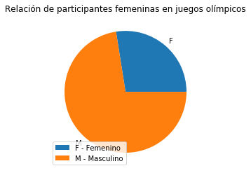

```python
%matplotlib inline
data.Sexo.groupby(data.Sexo).count().plot(kind="pie", legend="Reverse")
plt.title("Relación de participantes femeninas en juegos olímpicos")
plt.legend(["F - Femenino", "M - Masculino"])
plt.ylabel("")
plt.show()
```

De un total de 271116 participantes en los juegos olímpicos, desde los años 1986 hasta el 2016 han participado 74522 mujeres, esto representa un 27.49% de la muestra.  
En la gráfica anterior se puede visualizar la relación entre participantes mujeres y participantes hombres, en el, se distingue la proporción entre ambos sexos.

15. ¿En qué temporada de los Juegos Olímpicos compitieron por primera vez las atletas femeninas?

```python
temporada = mujeres_df.sort_values("Año", ascending=True)
temporada.iloc[0:1, 9:12]
```

|  | Año | Temporada | Ciudad |
| --- | --- | --- | --- |
| 71787 | 1900 | Summer | Paris |

Los primeros juegos olímpicos que registra la participación de mujeres corresponde a los realizados en el verano del año 1900 en Francia.

16. ¿Cuál es el porcentaje que representa la participación total de atletas femeninas en la primera temporada, respecto a los atletas masculinos?

```python
anio = data.loc[:, "Año"]==1900
primera_temporada = data.loc[anio]
filtro_femenino = primera_temporada.loc[:, "Sexo"]=="F"
filtro_masculino = primera_temporada.loc[:, "Sexo"]=="M"
mujeres_df = primera_temporada.loc[filtro_femenino]
hombres_df = primera_temporada.loc[filtro_masculino]
porcentaje_mujeres = round(((len(mujeres_df)/len(primera_temporada))*100),2)
porcentaje_hombres = round(((len(hombres_df)/len(primera_temporada))*100),2)
print("Total de participantes en juegos olímpicos de 1900: {}".format(len(primera_temporada)))
print("Total participantes hombres: {} ({}%)".format(len(hombres_df), porcentaje_hombres))
print("Total participantes mujeres: {} ({}%)".format(len(mujeres_df), porcentaje_mujeres))
```

```
Total de participantes en juegos olímpicos de 1900: 1936
Total participantes hombres: 1903 (98.3%)
Total participantes mujeres: 33 (1.7%)
```

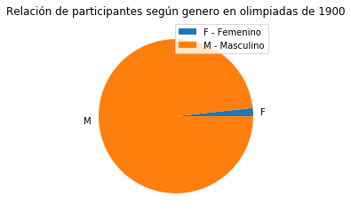

```python
%matplotlib inline
primera_temporada.Sexo.groupby(primera_temporada.Sexo).count().plot(kind="pie", legend="Reverse")
plt.title("Relación de participantes según genero en olimpiadas de 1900")
plt.legend(["F - Femenino", "M - Masculino"])
plt.ylabel("")
plt.show()
```

En la primera temporada de los juegos olímpicos del año 1896 en Atenas, no hubo participación femenina, por lo tanto para revisar la participación de mujeres en los juegos, se revisará los realizados en Francia en 1900, donde si estubieron participando atletas femeninas.  
En Francia participaron 1936 atletas, de los cuales, 1903 fueron hombres representando un 98.3%, mientras tanto tan solo el 1.7% corresponde a atletas femeninas con una cantidad de 33 participantes.

17. ¿Cuál es el porcentaje de las atletas femeninas en Río de Janeiro 2016, respecto al total de deportista?

```python
anio = data.loc[:, "Año"]==2016
primera_temporada = data.loc[anio]
filtro_femenino = primera_temporada.loc[:, "Sexo"]=="F"
filtro_masculino = primera_temporada.loc[:, "Sexo"]=="M"
mujeres_df = primera_temporada.loc[filtro_femenino]
hombres_df = primera_temporada.loc[filtro_masculino]
porcentaje_mujeres = round(((len(mujeres_df)/len(primera_temporada))*100),2)
porcentaje_hombres = round(((len(hombres_df)/len(primera_temporada))*100),2)
print("Total de participantes en juegos olímpicos de 2016: {}".format(len(primera_temporada)))
print("Total participantes hombres: {} ({}%)".format(len(hombres_df), porcentaje_hombres))
print("Total participantes mujeres: {} ({}%)".format(len(mujeres_df), porcentaje_mujeres))
```

```
Total de participantes en juegos olímpicos de 2016: 13688
Total participantes hombres: 7465 (54.54%)
Total participantes mujeres: 6223 (45.46%)
```

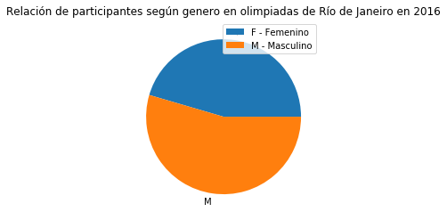

```python
%matplotlib inline
primera_temporada.Sexo.groupby(primera_temporada.Sexo).count().plot(kind="pie", legend="Reverse")
plt.title("Relación de participantes según genero en olimpiadas de Río de Janeiro en 2016")
plt.legend(["F - Femenino", "M - Masculino"])
plt.ylabel("")
plt.show()
```

En RRío de Janeiro participaron un total de 13688 atletas, la presencia femenina fue de un 45.46% con 6223 atletas, en cambio la participación de los hombres corresponde al 54.54% con 7465 competidores.

18. ¿Sabes quién es el deportista que más medallas de oro ha ganado en los Juegos Olímpicos hasta el momento? Si quieres saber quién ha ganado más medallas en los Juegos Olímpicos, no dudes en aplicar un análisis que arroje los 10 deportistas con más medallas olímpicas de oro en sus palmareses.

```python
filtro_medallas = data.loc[:, "Medalla"]=="Gold"
medallistas = data.loc[filtro_medallas]
print("Rankin de deportistas con mayor cantidad de medallas de oros ganadas.")
medallistas["NombreAtleta"].value_counts().head(10)
```

```
Rankin de deportistas con mayor cantidad de medallas de oros ganadas.
```

```
Michael Fred Phelps, II                            23
Raymond Clarence "Ray" Ewry                        10
Frederick Carlton "Carl" Lewis                      9
Paavo Johannes Nurmi                                9
Larysa Semenivna Latynina (Diriy-)                  9
Mark Andrew Spitz                                   9
Usain St. Leo Bolt                                  8
Birgit Fischer-Schmidt                              8
Ole Einar Bjrndalen                                 8
Jennifer Elisabeth "Jenny" Thompson (-Cumpelik)     8
Name: NombreAtleta, dtype: int64
```

```python
medallas = data.loc[:, "Medalla"].isin(["Gold"])
campos =["NombreAtleta", "Equipo", "JuegosOlimpicos", "Ciudad", "Deporte", "Competencia", "Medalla"]
```

```python
def mostrar_medallas(nombre_atleta, apellido_atleta):
    nombre = data.loc[:, "NombreAtleta"].str.contains(nombre_atleta)
    apellido = data.loc[:, "NombreAtleta"].str.contains(apellido_atleta)
    atleta  = data.loc[nombre & apellido & medallas]
    return atleta[campos]
```

### Michael Phelps

```python
mostrar_medallas("Michael", "Phelps").head(25)
```

|  | NombreAtleta | Equipo | JuegosOlimpicos | Ciudad | Deporte | Competencia | Medalla |
| --- | --- | --- | --- | --- | --- | --- | --- |
| 187890 | Michael Fred Phelps, II | United States | 2004 Summer | Athina | Swimming | Swimming Men's 4 x 200 metres Freestyle Relay | Gold |
| 187891 | Michael Fred Phelps, II | United States | 2004 Summer | Athina | Swimming | Swimming Men's 100 metres Butterfly | Gold |
| 187892 | Michael Fred Phelps, II | United States | 2004 Summer | Athina | Swimming | Swimming Men's 200 metres Butterfly | Gold |
| 187893 | Michael Fred Phelps, II | United States | 2004 Summer | Athina | Swimming | Swimming Men's 200 metres Individual Medley | Gold |
| 187894 | Michael Fred Phelps, II | United States | 2004 Summer | Athina | Swimming | Swimming Men's 400 metres Individual Medley | Gold |
| 187895 | Michael Fred Phelps, II | United States | 2004 Summer | Athina | Swimming | Swimming Men's 4 x 100 metres Medley Relay | Gold |
| 187896 | Michael Fred Phelps, II | United States | 2008 Summer | Beijing | Swimming | Swimming Men's 200 metres Freestyle | Gold |
| 187897 | Michael Fred Phelps, II | United States | 2008 Summer | Beijing | Swimming | Swimming Men's 4 x 100 metres Freestyle Relay | Gold |
| 187898 | Michael Fred Phelps, II | United States | 2008 Summer | Beijing | Swimming | Swimming Men's 4 x 200 metres Freestyle Relay | Gold |
| 187899 | Michael Fred Phelps, II | United States | 2008 Summer | Beijing | Swimming | Swimming Men's 100 metres Butterfly | Gold |
| 187900 | Michael Fred Phelps, II | United States | 2008 Summer | Beijing | Swimming | Swimming Men's 200 metres Butterfly | Gold |
| 187901 | Michael Fred Phelps, II | United States | 2008 Summer | Beijing | Swimming | Swimming Men's 200 metres Individual Medley | Gold |
| 187902 | Michael Fred Phelps, II | United States | 2008 Summer | Beijing | Swimming | Swimming Men's 400 metres Individual Medley | Gold |
| 187903 | Michael Fred Phelps, II | United States | 2008 Summer | Beijing | Swimming | Swimming Men's 4 x 100 metres Medley Relay | Gold |
| 187905 | Michael Fred Phelps, II | United States | 2012 Summer | London | Swimming | Swimming Men's 4 x 200 metres Freestyle Relay | Gold |
| 187906 | Michael Fred Phelps, II | United States | 2012 Summer | London | Swimming | Swimming Men's 100 metres Butterfly | Gold |
| 187908 | Michael Fred Phelps, II | United States | 2012 Summer | London | Swimming | Swimming Men's 200 metres Individual Medley | Gold |
| 187910 | Michael Fred Phelps, II | United States | 2012 Summer | London | Swimming | Swimming Men's 4 x 100 metres Medley Relay | Gold |
| 187911 | Michael Fred Phelps, II | United States | 2016 Summer | Rio de Janeiro | Swimming | Swimming Men's 4 x 100 metres Freestyle Relay | Gold |
| 187912 | Michael Fred Phelps, II | United States | 2016 Summer | Rio de Janeiro | Swimming | Swimming Men's 4 x 200 metres Freestyle Relay | Gold |
| 187914 | Michael Fred Phelps, II | United States | 2016 Summer | Rio de Janeiro | Swimming | Swimming Men's 200 metres Butterfly | Gold |
| 187915 | Michael Fred Phelps, II | United States | 2016 Summer | Rio de Janeiro | Swimming | Swimming Men's 200 metres Individual Medley | Gold |
| 187916 | Michael Fred Phelps, II | United States | 2016 Summer | Rio de Janeiro | Swimming | Swimming Men's 4 x 100 metres Medley Relay | Gold |

### Raymond Clarence

```python
mostrar_medallas("Raymond", "Clarence").head(15)
```

|  | NombreAtleta | Equipo | JuegosOlimpicos | Ciudad | Deporte | Competencia | Medalla |
| --- | --- | --- | --- | --- | --- | --- | --- |
| 65574 | Raymond Clarence "Ray" Ewry | United States | 1900 Summer | Paris | Athletics | Athletics Men's Standing High Jump | Gold |
| 65575 | Raymond Clarence "Ray" Ewry | United States | 1900 Summer | Paris | Athletics | Athletics Men's Standing Long Jump | Gold |
| 65576 | Raymond Clarence "Ray" Ewry | United States | 1900 Summer | Paris | Athletics | Athletics Men's Standing Triple Jump | Gold |
| 65577 | Raymond Clarence "Ray" Ewry | United States | 1904 Summer | St. Louis | Athletics | Athletics Men's Standing High Jump | Gold |
| 65578 | Raymond Clarence "Ray" Ewry | United States | 1904 Summer | St. Louis | Athletics | Athletics Men's Standing Long Jump | Gold |
| 65579 | Raymond Clarence "Ray" Ewry | United States | 1904 Summer | St. Louis | Athletics | Athletics Men's Standing Triple Jump | Gold |
| 65580 | Raymond Clarence "Ray" Ewry | United States | 1906 Summer | Athina | Athletics | Athletics Men's Standing High Jump | Gold |
| 65581 | Raymond Clarence "Ray" Ewry | United States | 1906 Summer | Athina | Athletics | Athletics Men's Standing Long Jump | Gold |
| 65582 | Raymond Clarence "Ray" Ewry | United States | 1908 Summer | London | Athletics | Athletics Men's Standing High Jump | Gold |
| 65583 | Raymond Clarence "Ray" Ewry | United States | 1908 Summer | London | Athletics | Athletics Men's Standing Long Jump | Gold |

### Mark Andrew Spitz

```python
mostrar_medallas("Mark","Spitz").head(10)
```

|  | NombreAtleta | Equipo | JuegosOlimpicos | Ciudad | Deporte | Competencia | Medalla |
| --- | --- | --- | --- | --- | --- | --- | --- |
| 226658 | Mark Andrew Spitz | United States | 1968 Summer | Mexico City | Swimming | Swimming Men's 4 x 100 metres Freestyle Relay | Gold |
| 226659 | Mark Andrew Spitz | United States | 1968 Summer | Mexico City | Swimming | Swimming Men's 4 x 200 metres Freestyle Relay | Gold |
| 226662 | Mark Andrew Spitz | United States | 1972 Summer | Munich | Swimming | Swimming Men's 100 metres Freestyle | Gold |
| 226663 | Mark Andrew Spitz | United States | 1972 Summer | Munich | Swimming | Swimming Men's 200 metres Freestyle | Gold |
| 226664 | Mark Andrew Spitz | United States | 1972 Summer | Munich | Swimming | Swimming Men's 4 x 100 metres Freestyle Relay | Gold |
| 226665 | Mark Andrew Spitz | United States | 1972 Summer | Munich | Swimming | Swimming Men's 4 x 200 metres Freestyle Relay | Gold |
| 226666 | Mark Andrew Spitz | United States | 1972 Summer | Munich | Swimming | Swimming Men's 100 metres Butterfly | Gold |
| 226667 | Mark Andrew Spitz | United States | 1972 Summer | Munich | Swimming | Swimming Men's 200 metres Butterfly | Gold |
| 226668 | Mark Andrew Spitz | United States | 1972 Summer | Munich | Swimming | Swimming Men's 4 x 100 metres Medley Relay | Gold |

19. ¿Cuál son los datos del primer atleta que se coronó campeón en los Juegos Olímpicos? Y en el apartado femenino ¿Quién fue?

```python
nombre = data.loc[:, "NombreAtleta"].str.contains("James")
apellido = data.loc[:, "NombreAtleta"].str.contains("Connolly")
anio = data.loc[:, "Año"]==1896
primer_medallista = data.loc[nombre & apellido & anio]
primer_medallista[campos]
```

|  | NombreAtleta | Equipo | JuegosOlimpicos | Ciudad | Deporte | Competencia | Medalla |
| --- | --- | --- | --- | --- | --- | --- | --- |
| 44062 | James Brendan Bennet Connolly | United States | 1896 Summer | Athina | Athletics | Athletics Men's High Jump | Silver |
| 44063 | James Brendan Bennet Connolly | United States | 1896 Summer | Athina | Athletics | Athletics Men's Long Jump | Bronze |
| 44064 | James Brendan Bennet Connolly | United States | 1896 Summer | Athina | Athletics | Athletics Men's Triple Jump | Gold |

El Estado Unidense James Connolly, fue el primer campeón olímpico al ganar medallas en las disciplinas de triple salto, salto alto y salto largo, esto lo logro el 06/04/1896.

```python
nombre = data.loc[:, "NombreAtleta"].str.contains("Charlotte")
apellido = data.loc[:, "NombreAtleta"].str.contains("Cooper")
primera_medallista = data.loc[nombre & apellido]
primera_medallista[campos]
```

|  | NombreAtleta | Equipo | JuegosOlimpicos | Ciudad | Deporte | Competencia | Medalla |
| --- | --- | --- | --- | --- | --- | --- | --- |
| 44448 | Charlotte Reinagle Cooper (-Sterry) | Great Britain | 1900 Summer | Paris | Tennis | Tennis Women's Singles | Gold |
| 44449 | Charlotte Reinagle Cooper (-Sterry) | Great Britain | 1900 Summer | Paris | Tennis | Tennis Mixed Doubles | Gold |

Charlotte Cooper fue la primera mujer en ganar un título olímpico, Ganó en la final a la francesa Hélène Prévost por 6-1, 7-5.  
En las mismas olimpiadas sumó otra victoria en la disciplina de dobles mixto con su compañero Reginald Doherty 6-2, 6-4, sobre Harold Mahony y Prévost.

20. ¿Cuáles son los 5 primeros países de Latinoamérica en cuanto a obtenciones de medallas de oro en todos los JJ.OO?

```python
lista_paises = ["Argentina", "Brazil", "Bolivia", "Chile", "Colombia", "Ecuador", "Paraguay", "Peru", "Uruguay", "Venezuela"]
paises_latinos  = data.loc[data["Equipo"].isin(lista_paises), ["Equipo", "Medalla"]]
paises_latinos["Equipo"].value_counts()
```

```
Brazil       3772
Argentina    3199
Colombia     1068
Chile         924
Venezuela     921
Uruguay       570
Peru          532
Ecuador       277
Bolivia       152
Paraguay      135
Name: Equipo, dtype: int64
```

[figure not shown]

```python
%matplotlib inline
paises_latinos.groupby("Equipo")["Equipo"].count().plot(kind="barh", legend="Reverse")
plt.xlabel("Cantidad de medallas")
plt.ylabel("Paises")
plt.title("Ranking de medallas obtenidas por paises latinoamericanos")
plt.show()
```

```python
print("Cantidad de tipo de medalla obtenidas por paises latinoamericanos:")
paises_latinos["Medalla"].value_counts()
```

```
Cantidad de tipo de medalla obtenidas por paises latinoamericanos:
```

```
Bronze    350
Silver    299
Gold      237
Name: Medalla, dtype: int64
```

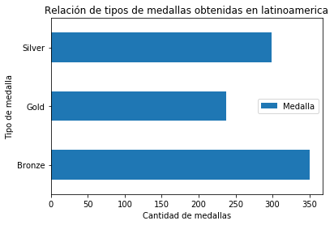

```python
%matplotlib inline
paises_latinos.groupby("Medalla")["Medalla"].count().plot(kind="barh", legend="Reverse")
plt.title("Relación de tipos de medallas obtenidas en latinoamerica")
plt.xlabel("Cantidad de medallas")
plt.ylabel("Tipo de medalla")
plt.show()
```

En la gráfica podemos distinguir que la mayor cantidad de medallas obtenidas por los paises latino americanos son de tipo bronce (350), seguidas por medallas de plata (299) y por último medallas de oro (237).

Por último se visualizarán los resultados separados por tipos de medallas y por paises.

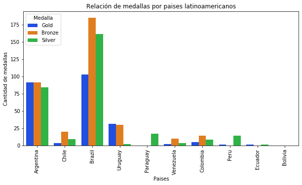

```python
fig=plt.subplots(figsize=(10,5))
d=sns.countplot(x='Equipo',data=paises_latinos,hue='Medalla',palette='bright')
m=plt.setp(d.get_xticklabels(),rotation=90)
plt.title("Relación de medallas por paises latinoamericanos")
plt.ylabel("Cantidad de medallas")
plt.xlabel("Paises")
plt.show()
```

# Configuración utilizada para esta evaluación.

```python
%load_ext watermark
%watermark
```

```
2020-05-06T17:05:16-04:00

CPython 3.7.6
IPython 7.13.0

compiler   : MSC v.1916 64 bit (AMD64)
system     : Windows
release    : 10
machine    : AMD64
processor  : Intel64 Family 6 Model 158 Stepping 10, GenuineIntel
CPU cores  : 12
interpreter: 64bit
```